# Jackson Heart Study diabetes analysis

Author

Oscar Hernandez Mata

```r
library(tidyverse)
library(dplyr)
library(haven)
library(haven)
analysis1 <- read_sas("analysis1.sas7bdat",
    NULL)
library(ggplot2)
library(fastDummies)
library(data.table)
library(equatiomatic)
library(lindia)
library(car)
library(sjPlot)
library(nnet)
library(lmtest)
library(AER)
library(mlogit)
library(MASS)
library(brant)
```

#### 1. I modeled diabetic status (*Diabetes*; 0=non-diabetic, 1=diabetic) as a function of age (*age*; years), weight (*weight*; kg), hypertension status (*HTN*; 0=normotensive, 1=hypertensive), and fasting HDL categorization (*hdl3cat*; 0=low, 1=normal, 2=high), and the interactions between (1) weight and hypertension and (2) weight and fasting HDL categorization.

```r
data1=analysis1%>%dplyr::select(
Diabetes,
age,
weight,
HTN,
hdl3cat
)%>%
  na.omit()

data1 = dummy_cols(data1, select_columns = c("hdl3cat"))

setnames(data1, new=c('low', 'normal', 'high'),
          old=c('hdl3cat_0', 'hdl3cat_1', 'hdl3cat_2'))

m1=glm(Diabetes~age+weight+HTN+low+high+weight:HTN+weight:low+weight:high, data=data1, family = "binomial")
summary(m1)
```

```
Call:
glm(formula = Diabetes ~ age + weight + HTN + low + high + weight:HTN +
    weight:low + weight:high, family = "binomial", data = data1)

Deviance Residuals:
    Min       1Q   Median       3Q      Max
-1.5627  -0.6750  -0.4273  -0.2460   2.6743

Coefficients:
             Estimate Std. Error z value Pr(>|z|)
(Intercept) -8.003330   0.721374 -11.095  < 2e-16 ***
age          0.042307   0.005913   7.155 8.34e-13 ***
weight       0.034193   0.006040   5.661 1.50e-08 ***
HTN          2.122658   0.573222   3.703 0.000213 ***
low          0.600167   0.600528   0.999 0.317601
high         0.975097   0.685338   1.423 0.154795
weight:HTN  -0.011746   0.005656  -2.077 0.037811 *
weight:low  -0.002073   0.005909  -0.351 0.725697
weight:high -0.011861   0.007221  -1.642 0.100504
---
Signif. codes:  0 '***' 0.001 '**' 0.01 '*' 0.05 '.' 0.1 ' ' 1

(Dispersion parameter for binomial family taken to be 1)

    Null deviance: 2221.4  on 2454  degrees of freedom
Residual deviance: 1959.4  on 2446  degrees of freedom
AIC: 1977.4

Number of Fisher Scoring iterations: 5
```

```r
c1=coefficients(m1)
c1
```

```
(Intercept)         age      weight         HTN         low        high
-8.00333002  0.04230680  0.03419322  2.12265771  0.60016705  0.97509711
 weight:HTN  weight:low weight:high
-0.01174637 -0.00207325 -0.01186066
```

```r
round(exp(coefficients(m1)), 4)
```

```
(Intercept)         age      weight         HTN         low        high
     0.0003      1.0432      1.0348      8.3533      1.8224      2.6514
 weight:HTN  weight:low weight:high
     0.9883      0.9979      0.9882
```

```r
extract_eq(m1, use_coefs = TRUE)
```

$$\log\left[ \frac { \widehat{P( \operatorname{Diabetes} = \operatorname{1} )} }{ 1 - \widehat{P( \operatorname{Diabetes} = \operatorname{1} )} } \right] = -8 + 0.04(\operatorname{age}) + 0.03(\operatorname{weight}) + 2.12(\operatorname{HTN}) + 0.6(\operatorname{low}) + 0.98(\operatorname{high}) - 0.01(\operatorname{weight} \times \operatorname{HTN}) + 0(\operatorname{weight} \times \operatorname{low}) - 0.01(\operatorname{weight} \times \operatorname{high})$$

Interpretation of the odds ratio.

For every year increase in age, the odds of individuals becoming diabetics increase by 4.3%. For every kg increase in weight, the odds of individuals becoming diabetic increase by 3.5%. The odds of being diabetic for someone hypertensive are 735% higher than for someone who is normotensive. Individuals with low fasting HDL cholesterol are estimated to have 82.24% higher odds of becoming diabetic compared to those with normal fasting HDL cholesterol. Individuals with high fasting HDL cholesterol are estimated to have 165.1% higher odds of being diabetic compared to those with normal fasting HDL cholesterol. Compared to normotensive for each kg increase in weight for hypertensive individuals, the odds of becoming diabetic decrease by 1.2%. Compared to individuals with normal fasting HDL cholesterol, for each kg increase in weight for individuals with low fasting HDL cholesterol, the odds of becoming diabetic are estimated to decrease by .21%. Compared to individuals with normal fasting HDL cholesterol, for each kg increase in weight for individuals with high fasting HDL cholesterol, the odds of becoming diabetic are estimated to decrease by 1.18%.

#### 2. I performed the appropriate hypothesis test to determine if the interaction between weight and hypertension status is significant. Test at the $\alpha=0.05$ level.

```r
full_int1=glm(Diabetes~age+weight+HTN+low+high+weight:HTN, data=data1, family = "binomial")
reduced_int1=glm(Diabetes~age+weight+HTN+low+high, data=data1, family = "binomial")
anova(reduced_int1, full_int1, test = "Chisq")
```

```
Analysis of Deviance Table

Model 1: Diabetes ~ age + weight + HTN + low + high
Model 2: Diabetes ~ age + weight + HTN + low + high + weight:HTN
  Resid. Df Resid. Dev Df Deviance Pr(>Chi)
1      2449     1966.8
2      2448     1962.4  1   4.3949  0.03605 *
---
Signif. codes:  0 '***' 0.001 '**' 0.01 '*' 0.05 '.' 0.1 ' ' 1
```

I calculated p-value=0.036, which is less than alpha=0.05. Thus, I conclude that the interaction between weight and hypertension status is significant.

#### 3. I performed the appropriate hypothesis test to determine if the interaction between weight and fasting HDL categorization is significant. Test at the $\alpha=0.05$ level.

```r
full_int2=glm(Diabetes~age+weight+HTN+low+high+weight:low+weight:high, data=data1, family = "binomial")
reduced_int2=glm(Diabetes~age+weight+HTN+low+high, data=data1, family = "binomial")
anova(reduced_int2, full_int2, test = "Chisq")
```

```
Analysis of Deviance Table

Model 1: Diabetes ~ age + weight + HTN + low + high
Model 2: Diabetes ~ age + weight + HTN + low + high + weight:low + weight:high
  Resid. Df Resid. Dev Df Deviance Pr(>Chi)
1      2449     1966.8
2      2447     1963.7  2   3.0581   0.2167
```

I calculated p-value=0.21, which is greater than alpha=0.05. Thus, I conclude that the interaction between weight and fasting HDL categorization is not significant.

#### 4. I constructed an data visualization for cases where someone weighted 70kg, 90kg, and 110kg.

```r
c1
```

```
(Intercept)         age      weight         HTN         low        high
-8.00333002  0.04230680  0.03419322  2.12265771  0.60016705  0.97509711
 weight:HTN  weight:low weight:high
-0.01174637 -0.00207325 -0.01186066
```

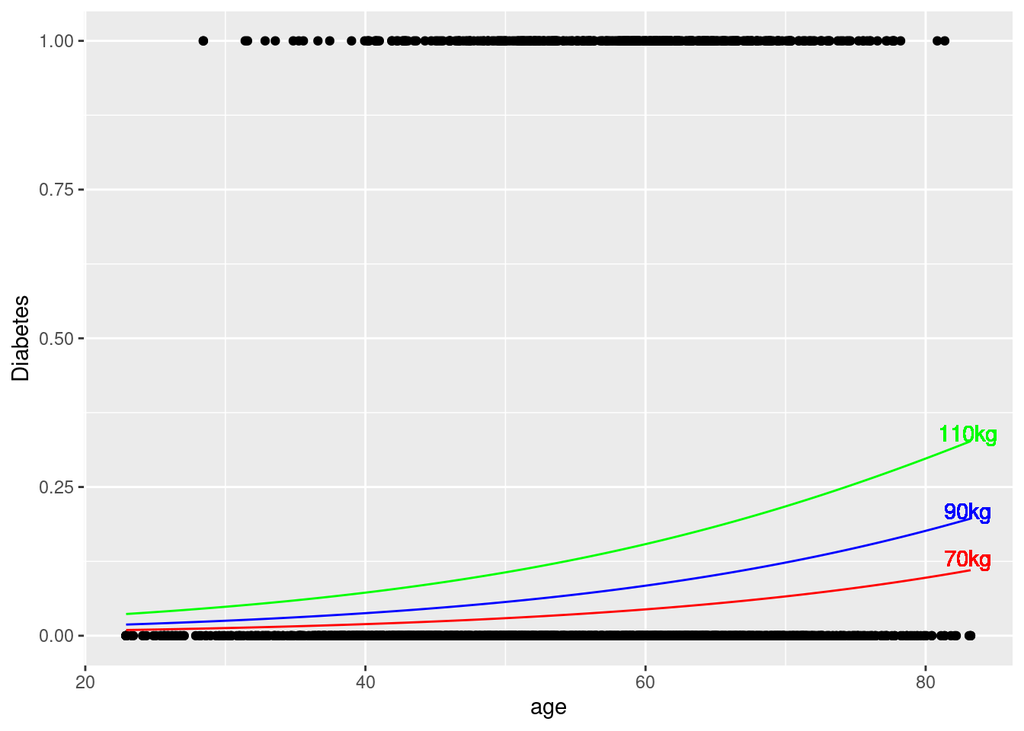

```r
data1=data1%>%mutate(
    pred_diab70kg=exp(c1[1]+c1[2]*age+c1[3]*70)/(1+exp(c1[1]+c1[2]*age+c1[3]*70)),
    pred_diab90kg=exp(c1[1]+c1[2]*age+c1[3]*90)/(1+exp(c1[1]+c1[2]*age+c1[3]*90)),
    pred_diab110kg=exp(c1[1]+c1[2]*age+c1[3]*110)/(1+exp(c1[1]+c1[2]*age+c1[3]*110))
    )
data1 %>% ggplot(aes(x = age, y = Diabetes)) +
geom_point() +
geom_line(aes(y = pred_diab70kg), color="red")+
geom_line(aes(y = pred_diab90kg), color="blue")+
geom_line(aes(y = pred_diab110kg), color="green")+
geom_text(aes(x = 83, y = 0.34, label = "110kg"), color="green", show.legend = FALSE) +
geom_text(aes(x = 83, y = 0.21, label = "90kg"), color="blue", show.legend = FALSE)+
geom_text(aes(x = 83, y = 0.13, label = "70kg"), color="red", show.legend = FALSE)
```

Th graph shows that as age increases the odds of becoming diabetic increase. But people that weight 110kg have more odds of becoming diabetic than those who weight 90kg or 70kg.

#### 5. I used ordinal logistic regression to model diabetic status (*diab3cat*; 0=non-diabetic, 1=pre-diabetic, 2=diabetic) as a function of age (*age*; years), weight (*weight*; kg), hypertension status (*HTN*; 0=normotensive, 1=hypertensive), and fasting HDL categorization (*hdl3cat*; 0=low, 1=normal, 2=high).

```r
data3=analysis1%>%dplyr::select(
  diab3cat,
  age,
  weight,
  HTN,
  hdl3cat
)%>%
  na.omit()

data3 = dummy_cols(data3, select_columns = c("HTN", "hdl3cat"))

data3 = data3%>% mutate(diab3cat = factor(diab3cat, labels = c("non_diabetic", "pre_diabetic", "diabetic")))

setnames(data3, new=c('normotensive', 'hypertensive'),
          old=c('HTN_0', 'HTN_1'))

setnames(data3, new=c('low', 'normal', 'high'),
          old=c('hdl3cat_0', 'hdl3cat_1', 'hdl3cat_2'))

m3 = polr(diab3cat ~ age+ weight + hypertensive + low+high,
data = data3, Hess = TRUE)
summary(m3)
```

```
Call:
polr(formula = diab3cat ~ age + weight + hypertensive + low +
    high, data = data3, Hess = TRUE)

Coefficients:
                Value Std. Error t value
age           0.05135   0.004046  12.690
weight        0.02463   0.002077  11.855
hypertensive  0.63215   0.088765   7.122
low           0.29634   0.091990   3.221
high         -0.29093   0.107026  -2.718

Intercepts:
                          Value   Std. Error t value
non_diabetic|pre_diabetic  5.2916  0.3220    16.4323
pre_diabetic|diabetic      7.2568  0.3381    21.4653

Residual Deviance: 4497.656
AIC: 4511.656
```

```r
c3=coefficients(m3)
c3
```

```
         age       weight hypertensive          low         high
  0.05135104   0.02462510   0.63214793   0.29633841  -0.29092673
```

```r
round(exp(coefficients(m3)), 2)
```

```
         age       weight hypertensive          low         high
        1.05         1.02         1.88         1.34         0.75
```

```r
extract_eq(m3, use_coefs = TRUE)
```

$$\begin{aligned}
\log\left[ \frac { P( \operatorname{non\_diabetic} \geq \operatorname{pre\_diabetic} ) }{ 1 - P( \operatorname{non\_diabetic} \geq \operatorname{pre\_diabetic} ) } \right] &= 5.29 + 0.05(\operatorname{age}) + 0.02(\operatorname{weight}) + 0.63(\operatorname{hypertensive}) + 0.3(\operatorname{low}) - 0.29(\operatorname{high}) \\
\log\left[ \frac { P( \operatorname{pre\_diabetic} \geq \operatorname{diabetic} ) }{ 1 - P( \operatorname{pre\_diabetic} \geq \operatorname{diabetic} ) } \right] &= 7.26 + 0.05(\operatorname{age}) + 0.02(\operatorname{weight}) + 0.63(\operatorname{hypertensive}) + 0.3(\operatorname{low}) - 0.29(\operatorname{high})
\end{aligned}$$

#### 6. I checked for significant predictors of diabetic status?

```r
coeftest(m3)
```

```
z test of coefficients:

                            Estimate Std. Error z value  Pr(>|z|)
age                        0.0513510  0.0040465 12.6903 < 2.2e-16 ***
weight                     0.0246251  0.0020772 11.8550 < 2.2e-16 ***
hypertensive               0.6321479  0.0887648  7.1216 1.067e-12 ***
low                        0.2963384  0.0919904  3.2214  0.001276 **
high                      -0.2909267  0.1070260 -2.7183  0.006562 **
non_diabetic|pre_diabetic  5.2916285  0.3220267 16.4323 < 2.2e-16 ***
pre_diabetic|diabetic      7.2567531  0.3380692 21.4653 < 2.2e-16 ***
---
Signif. codes:  0 '***' 0.001 '**' 0.01 '*' 0.05 '.' 0.1 ' ' 1
```

I calculated p-value for all the predictors. They all are less than alpha=0.05. Therefore, they all are significant predictors of diabetic status.

#### 7. I found the odds ratios and corresponding 95% CIs for the predictors.

```r
round(exp(confint(m3)),4)
```

```
              2.5 % 97.5 %
age          1.0444 1.0611
weight       1.0208 1.0291
hypertensive 1.5815 2.2398
low          1.1232 1.6110
high         0.6058 0.9216
```

#### 8. Interpretations of the odds ratios found above.

For a one-year increase in age, the odds of individuals moving from a non-diabetic status to pre-diabetic status, or from a pre-diabetic status to a diabetic status increase by 5%. For every kg increase in weight, the odds of individuals moving from non-diabetic status to pre-diabetic status, or from pre-diabetic status to diabetic status increases by 2%. For any fixed diabetic status, the estimated odds that a hypertensive is in the diabetic direction rather than the non-diabetic direction is 1.88 times the estimated odds for normotensive individuals. For any fixed diabetic status, the estimated odds that individuals with low HDL cholesterol are in the diabetic direction rather than the non-diabetic direction is 1.34 times the estimated odds for individuals with normal HDL cholesterol. For any fixed diabetic status, the estimated odds that individuals with high HDL cholesterol are in the diabetic direction rather than the non-diabetic direction is 0.75 times the estimated odds for individuals with normal HDL cholesterol.